# Regression

Alan T. Arnholt

April 10, 2015

Consider the data frame `signdist` in the `PDS` package used in chapter 13.

```r
library(PDS)
head(signdist)
```

```
  Age Distance
1  18      510
2  20      590
3  22      560
4  23      510
5  23      460
6  25      490
```

```r
plot(Distance ~ Age, data = signdist)
mod <- lm(Distance ~ Age, data = signdist)
summary(mod)
```

```
Call:
lm(formula = Distance ~ Age, data = signdist)

Residuals:
    Min      1Q  Median      3Q     Max
-78.231 -41.710   7.646  33.552 108.831

Coefficients:
            Estimate Std. Error t value Pr(>|t|)
(Intercept) 576.6819    23.4709  24.570  < 2e-16 ***
Age          -3.0068     0.4243  -7.086 1.04e-07 ***
---
Signif. codes:  0 '***' 0.001 '**' 0.01 '*' 0.05 '.' 0.1 ' ' 1

Residual standard error: 49.76 on 28 degrees of freedom
Multiple R-squared:  0.642, Adjusted R-squared:  0.6292
F-statistic: 50.21 on 1 and 28 DF,  p-value: 1.041e-07
```

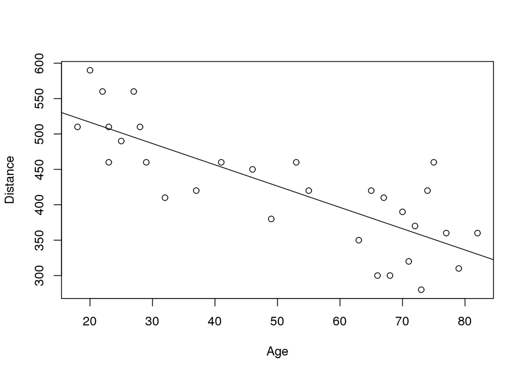

```r
abline(mod)
```

```r
cor(signdist$Distance, signdist$Age)
```

```
[1] -0.8012447
```

```r
cor.test(signdist$Distance, signdist$Age)
```

```
    Pearson's product-moment correlation

data:  signdist$Distance and signdist$Age
t = -7.086, df = 28, p-value = 1.041e-07
alternative hypothesis: true correlation is not equal to 0
95 percent confidence interval:
 -0.9013320 -0.6199255
sample estimates:
       cor
-0.8012447
```

Doing similar things with `ggplot2`.

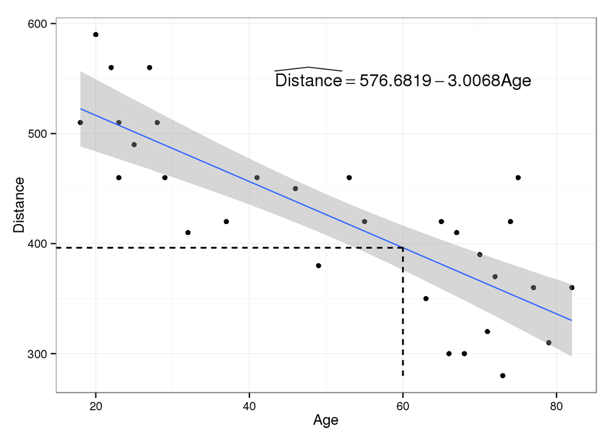

```r
library(ggplot2)
ggplot(data = signdist, aes(x = Age, y = Distance)) +
  geom_point() +
  theme_bw() +
  geom_smooth(method = "lm") +
  annotate("text", x = 60, y = 550, label="widehat(Distance)==576.6819 -3.0068*Age", parse = TRUE) +
  geom_segment(aes(x = 60, y = 280, xend = 60, yend = 576.6819 -3.0068*60), linetype = "dashed") +
  geom_segment(x = 60, y = 576.6819 -3.0068*60, xend = 10, yend = 576.6819 -3.0068*60, linetype = "dashed")
```

```r
predict(mod, newdata = data.frame(Age = 60), interval = "confidence", level = 0.90)
```

```
       fit      lwr      upr
1 396.2718 379.5068 413.0369
```

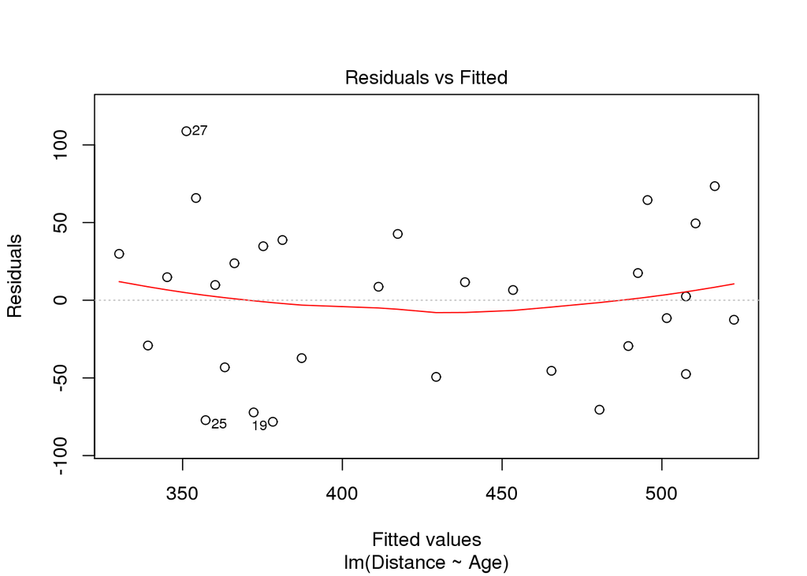

```r
plot(mod, which = 1)
```

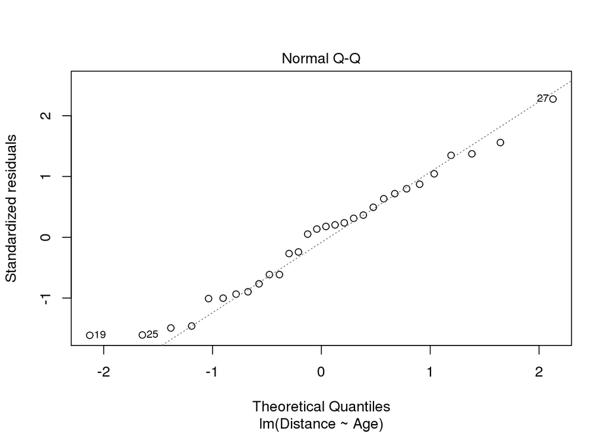

```r
plot(mod, which = 2)
```

```r
NDF <- fortify(mod)
head(NDF)
```

```
  Distance Age       .hat   .sigma      .cooksd  .fitted     .resid
1      510  18 0.11252182 50.60973 0.0045499458 522.5589 -12.558901
2      590  20 0.10321408 48.42613 0.1398244149 516.5452  73.454770
3      560  22 0.09448807 49.67731 0.0569412144 510.5316  49.468441
4      510  23 0.09034322 50.67225 0.0001350733 507.5247   2.475276
5      460  23 0.09034322 49.75909 0.0497921970 507.5247 -47.524724
6      490  25 0.08248982 50.62191 0.0026217441 501.5111 -11.511053
    .stdresid
1 -0.26790362
2  1.55876780
3  1.04468882
4  0.05215437
5 -1.00135168
6 -0.24149904
```

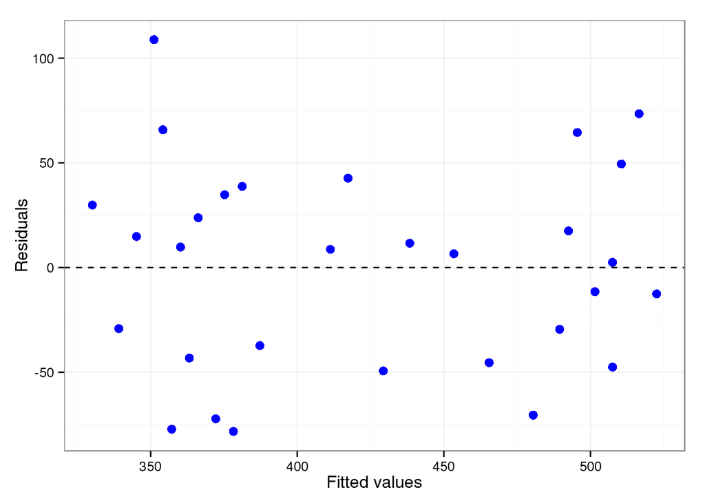

```r
ggplot(data = NDF, aes(x = .fitted, y = .resid)) +
  geom_point(color = "blue", size = 3) +
  theme_bw() +
  geom_hline(y = 0, linetype = "dashed") +
  labs(x = "Fitted values", y = "Residuals")
```

## Dichotomous Response Variable (Logistic Regression)

(Example taken from *An Introduction to Statistical Learning*)

> Goal: Predict whether an individual will default on his or her credit card payment.

```r
library(ISLR)
head(Default)
```

```
  default student   balance    income
1      No      No  729.5265 44361.625
2      No     Yes  817.1804 12106.135
3      No      No 1073.5492 31767.139
4      No      No  529.2506 35704.494
5      No      No  785.6559 38463.496
6      No     Yes  919.5885  7491.559
```

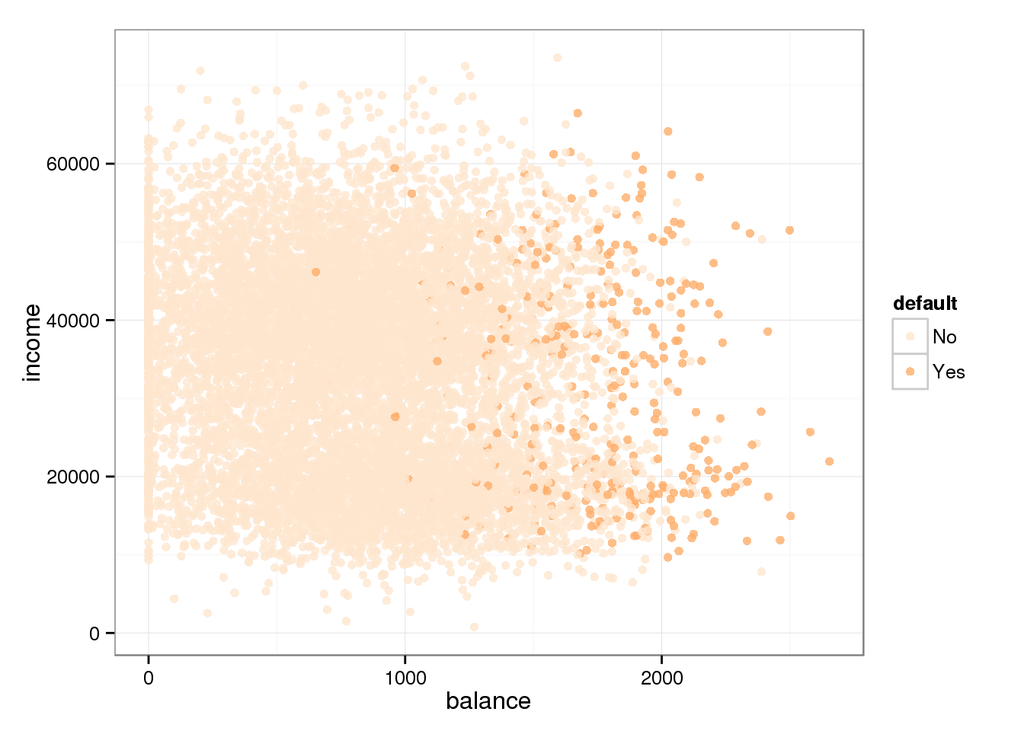

```r
ggplot(data = Default, aes(x = balance, y = income, colour = default)) +
  geom_point(alpha = 0.8) +
  theme_bw() +
  scale_color_brewer(palette=7)
```

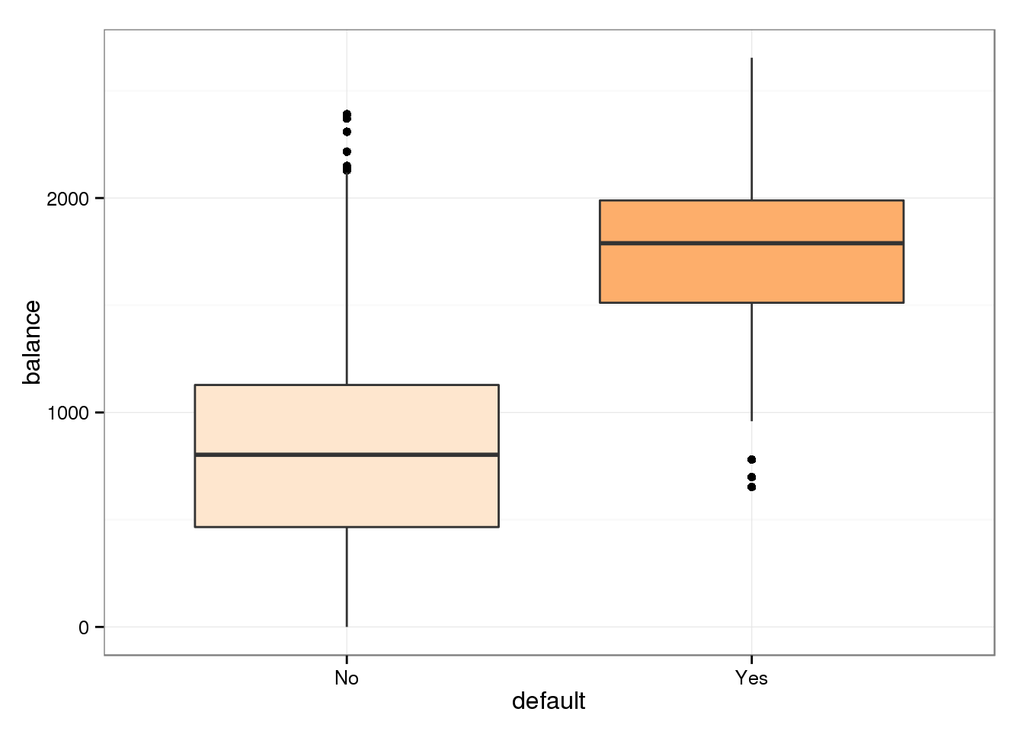

```r
ggplot(data = Default, aes(x = default, y = balance, fill = default)) +
  geom_boxplot() +
  theme_bw() +
  guides(fill = FALSE) +
  scale_fill_brewer(palette=7)
```

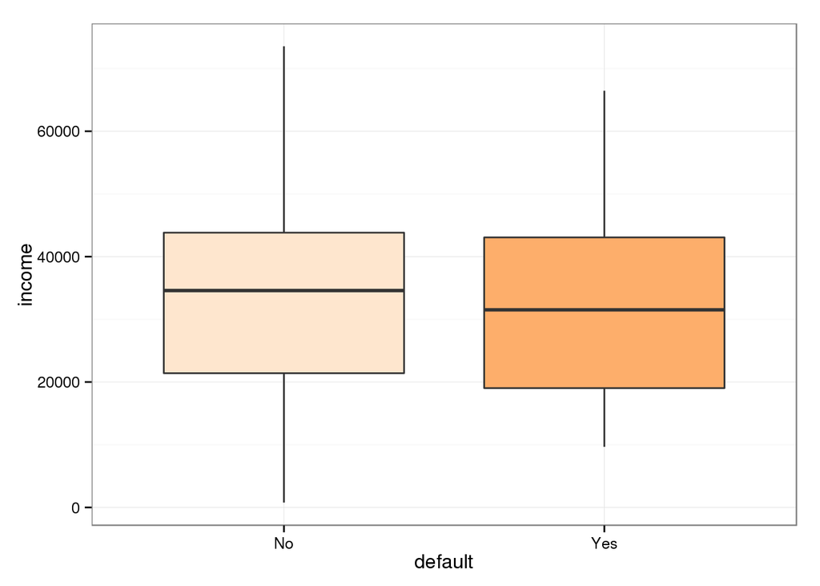

```r
ggplot(data = Default, aes(x = default, y = income, fill = default)) +
  geom_boxplot() +
  theme_bw() +
  guides(fill = FALSE) +
  scale_fill_brewer(palette=7)
```

> Why not regression?

```r
Default$defaultN <- ifelse(Default$default == "No", 0, 1)
Default$studentN <- ifelse(Default$student =="No", 0, 1)
summary(Default$defaultN)
```

```
   Min. 1st Qu.  Median    Mean 3rd Qu.    Max.
 0.0000  0.0000  0.0000  0.0333  0.0000  1.0000
```

```r
head(Default)
```

```
  default student   balance    income defaultN studentN
1      No      No  729.5265 44361.625        0        0
2      No     Yes  817.1804 12106.135        0        1
3      No      No 1073.5492 31767.139        0        0
4      No      No  529.2506 35704.494        0        0
5      No      No  785.6559 38463.496        0        0
6      No     Yes  919.5885  7491.559        0        1
```

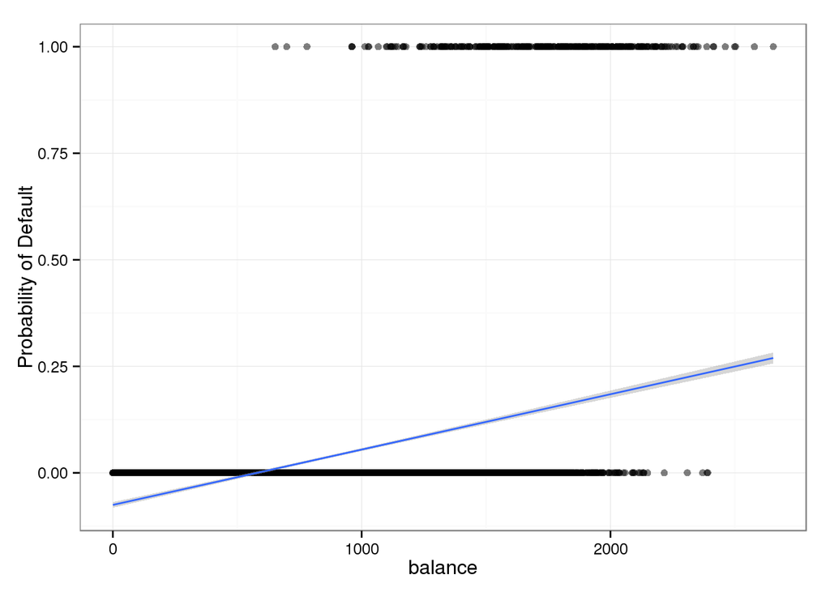

```r
ggplot(data = Default, aes(x = balance, y = defaultN)) +
  geom_point(alpha = 0.5) +
  theme_bw() +
  stat_smooth(method = "lm") +
  labs(y = "Probability of Default")
```

## Logistic regression

What we need is a function of $X$ that returns values between 0 and 1. Consider the *logistic function*

$p(X) = \frac{e^{\beta_0 + \beta_1X}}{1 + e^{\beta_0 + \beta_1X}}$

which will always produce an *S-shaped* curve regardless of the value of $X$.

Let $y = \beta_0 + \beta_1X$, then

$p(X)=\frac{e^y}{1 + e^y} \rightarrow p(X) + e^{y}p(X) = e^{y} \rightarrow p(X) = e^{y} - e^{y}p(X) \rightarrow \frac{p(X)}{1 - p(X)}=e^{y} = e^{\beta_0 + \beta_1X}$

$\text{log}\left(\frac{p(X)}{1 - p(X)}\right) = \beta_0 + \beta_1X$

The quantity $\text{log}\left(\frac{p(X)}{1 - p(X)}\right)$ is called the *log-odds* or *logit*, and the quantity $\frac{p(X)}{1 - p(X)}$ is called the odds.

NOTE: In regression, $\beta_1$ gives the average change in $Y$ associated with a one-unit increase in $X$. In a logistic regression model, increasing $X$ by one unit changes the log odds by $\beta_1$, or equivalently it multiplies the odds by $e^{\beta_1}$.

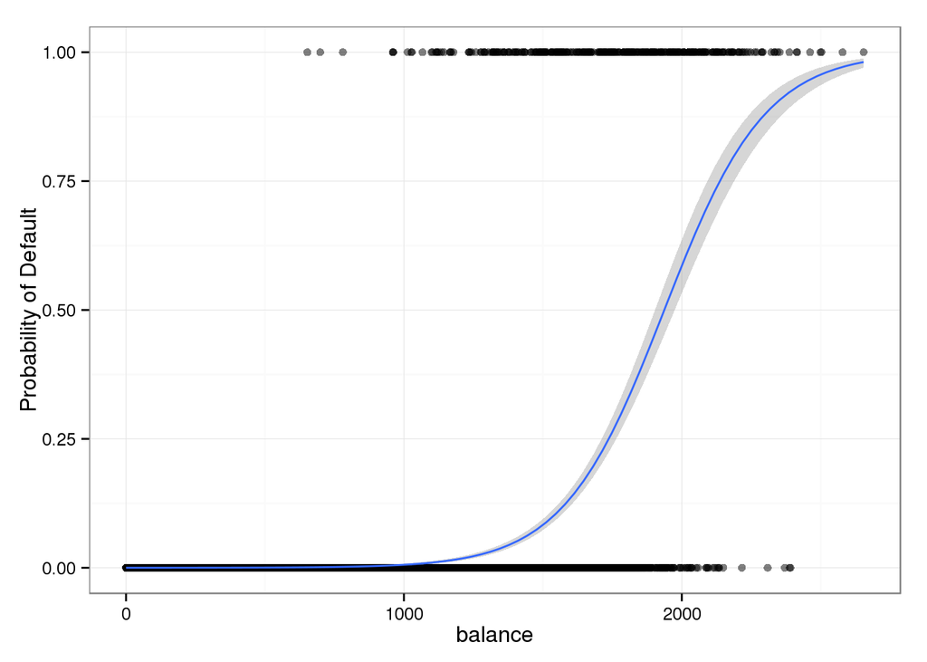

```r
ggplot(data = Default, aes(x = balance, y = defaultN)) +
  geom_point(alpha = 0.5) +
  theme_bw() +
  stat_smooth(method = "glm", family = "binomial") +
  labs(y = "Probability of Default")
```

The probability of default given `balance` can be written as P(default = Yes | balance).

```r
log.mod <- glm(default ~ balance, data = Default, family = "binomial")
summary(log.mod)
```

```
Call:
glm(formula = default ~ balance, family = "binomial", data = Default)

Deviance Residuals:
    Min       1Q   Median       3Q      Max
-2.2697  -0.1465  -0.0589  -0.0221   3.7589

Coefficients:
              Estimate Std. Error z value Pr(>|z|)
(Intercept) -1.065e+01  3.612e-01  -29.49   <2e-16 ***
balance      5.499e-03  2.204e-04   24.95   <2e-16 ***
---
Signif. codes:  0 '***' 0.001 '**' 0.01 '*' 0.05 '.' 0.1 ' ' 1

(Dispersion parameter for binomial family taken to be 1)

    Null deviance: 2920.6  on 9999  degrees of freedom
Residual deviance: 1596.5  on 9998  degrees of freedom
AIC: 1600.5

Number of Fisher Scoring iterations: 8
```

From the output note that $\hat{\beta} = 0.0054989$. This value indicates that an increase in `balance` is associated with an increase in the log odds of `default` by 0.0054989 units.

## Making predictions

Using the estimated coefficients, the predicted probability of default for an individual with a balance of $1,500 is

$\hat{p}(X) = \frac{e^{\hat{\beta_0} + \hat{\beta}_1X}}{1 + e^{\hat{\beta_0} + \hat{\beta_1}X}} = \frac{e^{-10.6513306+ 0.0054989 \times 1500}}{1 + e^{-10.6513306+ 0.0054989 \times 1500}} = 0.0829476.$

```r
predict(log.mod, newdata = data.frame(balance = 1500), type = "response")
```

```
         1
0.08294762
```

For an individual with a `balance` of $2,500, the probability of default is

$p(X) = 0.9567259$.

```r
predict(log.mod, newdata = data.frame(balance = 2500), type = "response")
```

```
        1
0.9567259
```

Are students more likely to default than non-students?

```r
mod2 <- glm(default ~ student, data = Default, family = "binomial")
summary(mod2)
```

```
Call:
glm(formula = default ~ student, family = "binomial", data = Default)

Deviance Residuals:
    Min       1Q   Median       3Q      Max
-0.2970  -0.2970  -0.2434  -0.2434   2.6585

Coefficients:
            Estimate Std. Error z value Pr(>|z|)
(Intercept) -3.50413    0.07071  -49.55  < 2e-16 ***
studentYes   0.40489    0.11502    3.52 0.000431 ***
---
Signif. codes:  0 '***' 0.001 '**' 0.01 '*' 0.05 '.' 0.1 ' ' 1

(Dispersion parameter for binomial family taken to be 1)

    Null deviance: 2920.6  on 9999  degrees of freedom
Residual deviance: 2908.7  on 9998  degrees of freedom
AIC: 2912.7

Number of Fisher Scoring iterations: 6
```

Note that the coefficient associated with `studentYes` is positive, and the associated *p-value* is statistically significant. This indicates that students tend to have higher default probabilities than non-students:

$\widehat{Pr}(\text{default = Yes }|\text{ student = Yes}) = \frac{e^{-3.5041278+ 0.4048871 \times 1}}{1 + e^{-3.5041278+ 0.4048871 \times 1}} = 0.0431386,$

```r
predict(mod2, newdata = data.frame(student = "Yes"), type = "response")
```

```
         1
0.04313859
```

$\widehat{Pr}(\text{default = Yes }|\text{ student = No}) = \frac{e^{-3.5041278+ 0.4048871 \times 0}}{1 + e^{-3.5041278+ 0.4048871 \times 1}} = 0.029195.$

```r
predict(mod2, newdata = data.frame(student = "No"), type = "response")
```

```
         1
0.02919501
```

## Multiple Logistic Regression

Consider a model that uses `balance`, `income`, and `student` to predict `default`.

```r
mlog.mod <- glm(default ~ balance + income + student, data = Default, family = "binomial")
summary(mlog.mod)
```

```
Call:
glm(formula = default ~ balance + income + student, family = "binomial",
    data = Default)

Deviance Residuals:
    Min       1Q   Median       3Q      Max
-2.4691  -0.1418  -0.0557  -0.0203   3.7383

Coefficients:
              Estimate Std. Error z value Pr(>|z|)
(Intercept) -1.087e+01  4.923e-01 -22.080  < 2e-16 ***
balance      5.737e-03  2.319e-04  24.738  < 2e-16 ***
income       3.033e-06  8.203e-06   0.370  0.71152
studentYes  -6.468e-01  2.363e-01  -2.738  0.00619 **
---
Signif. codes:  0 '***' 0.001 '**' 0.01 '*' 0.05 '.' 0.1 ' ' 1

(Dispersion parameter for binomial family taken to be 1)

    Null deviance: 2920.6  on 9999  degrees of freedom
Residual deviance: 1571.5  on 9996  degrees of freedom
AIC: 1579.5

Number of Fisher Scoring iterations: 8
```

There is a surprising result here. The *p-value* associated with `balance` and the `student` are very small, indicating that each of these variables is associated with the probability of `default`. However, the coefficient for `student` is negative, indicating that students are less likely to default than non-students. Yet, the coefficient in `mod2` for `student` was positive. How is it possible for the variable `student` to be associated with an *increase* in probability in `mod2` and a *decrease* in probability in `mlog.mod`?

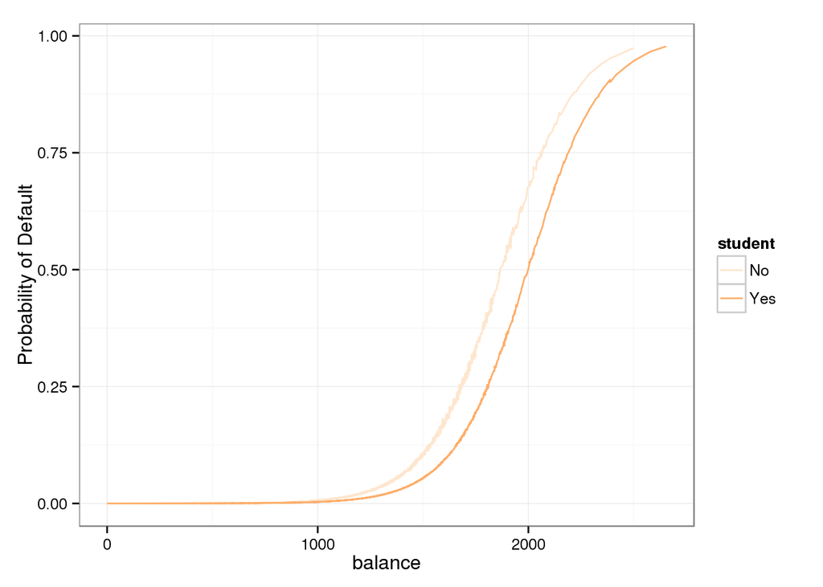

```r
Default$PrDef <- exp(predict(mlog.mod))/(1 + exp(predict(mlog.mod)))
# Or the following is the same
Default$PRdef <- predict(mlog.mod, type = "response")
ggplot(data = Default, aes(x = balance, y = default, color = student)) +
  geom_line(aes(x = balance, y = PrDef)) +
  scale_color_brewer(palette = 7) +
  theme_bw() +
  labs(y = "Probability of Default")
```

```r
library(dplyr)
Default <- Default %>%
  arrange(balance) %>%
  mutate(balanceFAC = cut(balance, breaks = seq(500, 2655, length.out = 10), include.lower = TRUE))
head(Default)
```

```
  default student balance   income defaultN studentN        PrDef
1      No      No       0 29275.27        0        0 2.080617e-05
2      No     Yes       0 21871.07        0        1 1.065494e-05
3      No      No       0 50265.31        0        0 2.217400e-05
4      No      No       0 49956.58        0        0 2.215325e-05
5      No      No       0 32481.54        0        0 2.100952e-05
6      No      No       0 43658.23        0        0 2.173402e-05
         PRdef balanceFAC
1 2.080617e-05       <NA>
2 1.065494e-05       <NA>
3 2.217400e-05       <NA>
4 2.215325e-05       <NA>
5 2.100952e-05       <NA>
6 2.173402e-05       <NA>
```

```r
T1 <- xtabs(~balanceFAC + default, data = Default, subset = student == "Yes")
T2 <- xtabs(~balanceFAC + default, data = Default, subset = student == "No")
SDR  <- T1[, 2]/apply(T1[, 1:2], 1, sum)
NSDR <- T2[, 2]/apply(T2[, 1:2], 1, sum)
BalanceM <- c(500+120, 739+120, 979+120, 1220+120, 1460+120, 1700+120, 1940+120, 2180+120, 2420+120)
DF <- data.frame(SDR, NSDR, BalanceM)
DF
```

```
                            SDR        NSDR BalanceM
(500,739]           0.000000000 0.001571092      620
(739,979]           0.000000000 0.003007519      859
(979,1.22e+03]      0.005454545 0.012252592     1099
(1.22e+03,1.46e+03] 0.025000000 0.043923865     1340
(1.46e+03,1.7e+03]  0.085365854 0.140056022     1580
(1.7e+03,1.94e+03]  0.248407643 0.394736842     1820
(1.94e+03,2.18e+03] 0.553571429 0.760000000     2060
(2.18e+03,2.42e+03] 0.818181818 0.888888889     2300
(2.42e+03,2.66e+03] 1.000000000 1.000000000     2540
```

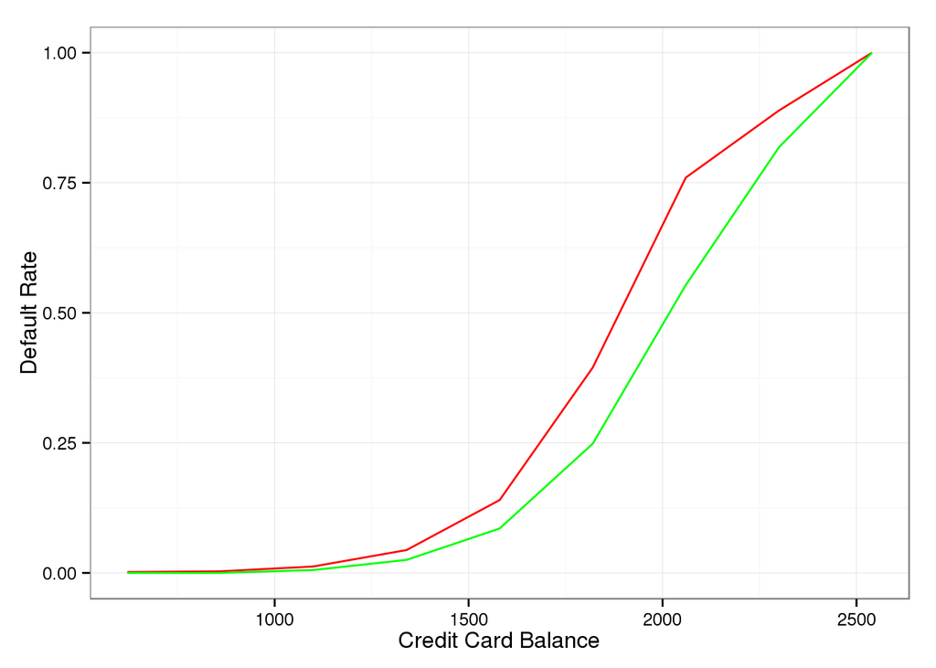

```r
ggplot(data = DF, aes(x = BalanceM, y = NSDR)) +
  geom_line(color = "red") +
  geom_line(aes(x = BalanceM, y = SDR), color = "green") +
  theme_bw() +
  labs(y = "Default Rate", x = "Credit Card Balance")
```

## Odds Ratio (OR)

The *odds ratio*, denoted OR, is the ratio of the odds for $X = 1$ to the odds for $X = 0$, and is given by the equation

$\text{OR}=\frac{\frac{p(1)}{1 - p(1)}}{\frac{p(0)}{1 - p(0)}}.$

Substituting  
$\frac{e^{\beta_0 + \beta_1}}{1 + e^{\beta_0 + \beta_1}}$ for $p(X=1)$, and $\frac{e^{\beta_0}}{1 + e^{\beta_0}}$ for $p(X=0)$, respectively, one can show that $\text{OR} = e^{\beta_1}.$

The odds ratio is widely used as a measure of association as it approximates how much more likely or unlikely (in terms of odds) it is for the outcome to be present among those subjects with $X = 1$ as compared to those subjects with $X = 0$.

Using the `mlog.mod` model, the response variable $Y$ is `default`, which denotes whether a credit card holder has defaulted (Yes/1) or not defaulted (No/0) on his/her current payment. The independent variable $X$ is `student`, which denotes whether the individual is a student (Yes/1) or is not a student (No/1). A hypothetical odds ratio in this scenario of 2 is interpreted to mean that the odds of default among students is two times greater than the odds of default among non-students.

An estimate of the odds ratio is

$\widehat{\text{OR}} = e^{-0.6467758} = 0.5237317.$

This is interpreted to mean that the odds of default among students is 0.5237317 the odds of default among non-students.